# Single Cell RNA-Seq Analysis Example

Andrew L. Stachyra

# Objective

This is an example demonstrating basic use of the Seurat package to analyze single cell RNA-Seq data.

# Input Data

The input data comprise 18 brain glioma cases that were downloaded from the publicly accessible “open” portion of the TCGA repository. The actual input data files used for this analysis are the raw transcript counts produced by the 10X Genomics Cell Ranger workflow. Each tumor sample is represented as an *m* x *n* sparse matrix, with gene names and/or other named transcription sites labeling the *m* rows, and individual cell bar codes labeling the *n* columns.

In practice, the number of samples (18) is inconveniently large to produce easily comprehensible visualizations, so for the sake of simplicity, this analysis will only make use of the first 6 sample files in the TCGA download package. Furthermore, the clustering analysis runs a PCA algorithm over all cells across all samples, and as the number of samples grows, the number of cells becomes prohibitively large for the PCA algorithm. So in addition to limiting the number of sample files, this analysis will also downsample across the cell bar codes as well.

# Analysis Steps

The analysis is logically divided into a series of discrete steps:

## Step 1: Load Packages and Metadata

We start by loading necessary library packages and a metadata table the gives the correspondences between sample ID and the directory UUID where each sample is saved.

```r
suppressMessages(library(tidyverse))
# The %>% operator is defined by tidyverse, so we only use it after
# tidyverse is loaded
library(Seurat) %>% suppressMessages()
library(cowplot) %>% suppressMessages()

# Contains mapping between sample ID and uuid folder name
sample_sheet <- 'metadata/sample_sheet/gdc_sample_sheet.2024-01-05.tsv'
# Limit ourselves to 6 out of 18 samples, initially
smp_subset <- c('C3L-03405-01', 'C3N-03184-02', 'C3L-02705-71', 'C3N-01814-01',
                'C3N-02784-01', 'C3N-02190-01')
smpsht <- read_delim(sample_sheet, delim='\t',
                     show_col_types=FALSE) %>%
          filter(`Sample ID` %in% smp_subset)
```

## Step 2: Read Sample Files Into A List of Seurat Objects

Next, we read the data into a list of Seurat objects. Unfortunately, we have to throw away 4/5 of cells, because the data scaling step that happens later on is extremely memory intensive, and R will run out of memory unless we limit the size of the input data.

```r
sobj <- list()
for(ii in 1:nrow(smpsht)) {
  # Data from TCGA unpacks into a directory structure which follows the
  # pattern: <uuid_folder>/raw_feature_bc_matrix/
  infolder <- paste0('data/', deframe(smpsht[ii,"File ID"]),
                     '/raw_feature_bc_matrix')
  inmtx <- Read10X(infolder)
  # Slice only every 5th column in order to limit the size of the input data
  inmtx <- inmtx[,seq(5,ncol(inmtx),5)]
  # Include a row for each feature (where "feature" typically means a known
  # gene name or a named transcription site) only if there are non-zero
  # transcript count values occurring in at least 30 cell columns.  Likewise,
  # include each barcoded cell column only if there are non-zero transcript
  # counts corresponding to at least 100 unique features in that column.
  # Omit warning about substituting illegal underscores with dashes.
  sobj[[ii]] <- CreateSeuratObject(counts=inmtx, min.cells=30,
                                   min.features=100) %>%
                suppressWarnings()
  # Add an identifier to the newly created Seurat object labeling the sample
  # ID that this data came from.  We need this later for keeping track of
  # what data came from where in the merged Seurat object.  First line
  # stores the label in a dedicated object attribute named "active.ident".
  # However, this attribute can be overwritten by later function calls, so
  # the second line writes it into the metadata table as well.
  Idents(sobj[[ii]]) <- deframe(smpsht[ii,"Sample ID"])
  sobj[[ii]][["Sample_ID"]] <- Idents(sobj[[ii]])
}
```

## Step 3: Merge Seurat Objects and Calculate Mitochondrial Gene Percentage

Ultimately we want to analyze all of the data together, so we merge it into a single Seurat object. Individual cells that have an excessively high fraction of their transcripts arising from mitochondrial genes are presumed to have something wrong with them, so we calculate this fraction for each cell, to enable filtering later.

```r
# Merge the individual sample objects into one merged object. Ignore warning
# about needing to append a suffix in order to distinguish duplicated barcode
# IDs across multiple samples.
mrgobj <- merge(x=sobj[[1]], y=sobj[2:length(sobj)]) %>%
          suppressWarnings()
rm(sobj)
# Calculate the percentage of features which are mitochondrial genes
# identified as gene names starting with prefix "MT-"
mrgobj[["percent.mt"]] <- PercentageFeatureSet(mrgobj, pattern="^MT-")
```

## Step 4: Visualize QC Information

Seurat includes a handy `VlnPlot()` convenience function for making violin plots, however there’s a [newly emerging school of thought](https://youtu.be/_0QMKFzW9fw?si=-wXHFk2LJDEfQzBe) that argues old-fashioned histograms are better at doing what violin plots were originally supposed to achieve.

I’ll demonstrate the use of the `VlnPlot()` function briefly here, and then show `ggplot2` histograms for comparison:

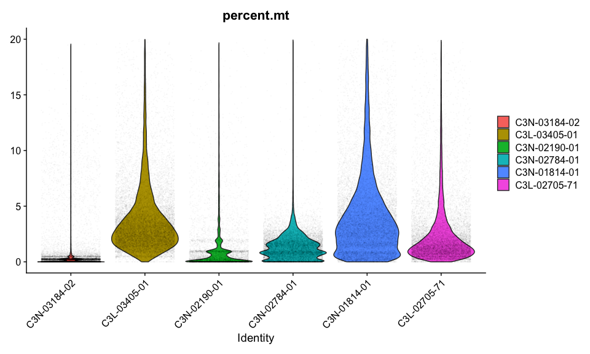

```r
# The number of cells included in these assays is very large, so make the
# individual data points nearly transparent at alpha=0.02.  Clip the y-axis
# at 20%, so we can zoom into the busiest and most detailed region of the plot
VlnPlot(mrgobj, features=c("percent.mt"), alpha=0.02, layer="counts",
        y.max=20)
```

And here’s the same data in the right-most figure column below, but plotted using `geom_histogram()`. Additionally, the `nCount_RNA` and `nFeature_RNA` values are also included in the left and middle columns, as these are computed by Seurat anyway by default. Seurat offers the capability to use these statistics as QC cutoff thresholds, but it’s not exactly clear what fundamentally drives the range of values that we observe, so although I’ve included blue dotted vertical lines to suggest where reasonable cutoff threshold values might be placed, I’ve tried to be conservative in my approach to throwing away data, and set those cutoffs rather loosely.

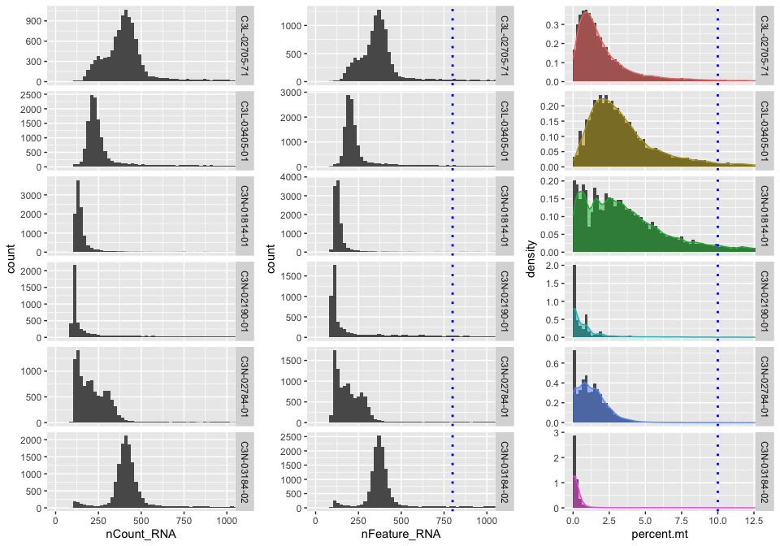

```r
# Grab the metadata data frame
df <- mrgobj@meta.data
plt <- list()
plt[["ncount"]] <- ggplot(data=df, aes(x=nCount_RNA)) +
                   geom_histogram(boundary=0, binwidth=20) +
                   facet_grid(rows=vars(Sample_ID), scales="free_y") +
                   coord_cartesian(xlim=c(0,1000))
plt[["nfeat"]] <- ggplot(data=df, aes(x=nFeature_RNA)) +
                  geom_histogram(boundary=0, binwidth=20) +
                  facet_grid(rows=vars(Sample_ID), scales="free_y") +
                  geom_vline(xintercept=800, color="blue", linetype="dotted",
                             linewidth=1) +
                  coord_cartesian(xlim=c(0,1000))
plt[["mt"]] <- ggplot(data=df, aes(x=percent.mt)) +
               geom_histogram(aes(y=after_stat(density)), boundary=0, binwidth=0.2) +
               geom_density(aes(color=Sample_ID, fill=Sample_ID),
                            alpha=0.5, bw=0.2) +
               facet_grid(rows=vars(Sample_ID), scales="free_y") +
               geom_vline(xintercept=10, color="blue", linetype="dotted",
                          linewidth=1) +
               coord_cartesian(xlim=c(0,12)) +
               theme(legend.position="none")
cwplt <- plot_grid(plt[["ncount"]], plt[["nfeat"]], plt[["mt"]], ncol=3,
                   rel_widths=c(0.333, 0.333, 0.333))
print(cwplt)
```

One thing that immediately stands out about the above data is that the typical number of transcript counts (left column) across all six samples is usually only slightly larger than the number of features with non-zero count values (middle column). This means that most features (i.e., gene transcript locations) will usually exhibit either zero or one counts per cell. This suggests we’re losing significant fidelity in terms of which transcripts are being expressed inside each individual cell: many cells will register a “0” across multiple transcripts that were actually being expressed within that cell, simply because the genomic coverage per cell was not sufficient to get all transcripts that were actually present up to the minimum observable count value of “1”.

The scatter plot below illustrates the relationship between the number of features and the number of counts observed in each cell. It’s approximately a 1-to-1 relationship; i.e., if a feature is observed in any given cell, most of the time it has just one transcript count associated with it.

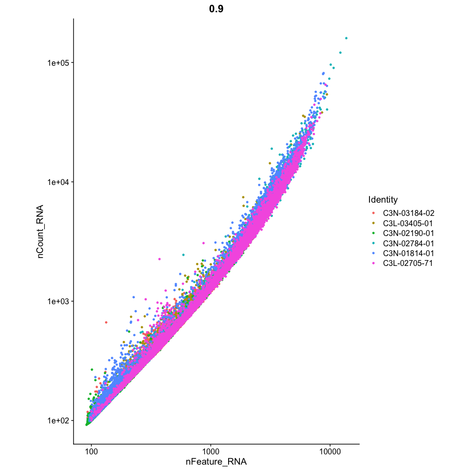

```r
plt_fvsc <- FeatureScatter(mrgobj, feature1="nFeature_RNA",
                           feature2="nCount_RNA") +
            scale_x_continuous(trans='log10') +
            scale_y_continuous(trans='log10') +
            coord_fixed(ratio=1)
print(plt_fvsc)
```

## Step 5: Apply QC Thresholds and Normalize Count Data

The QC thresholds defined above allow us to discard “outlier” cells in which something abnormal may be happening either with the cell itself, or with the assay procedure. After unwanted cells are discarded, the count data in each cell is normalized so that individual cells have approximately equal effective weight, in terms of the total number of transcripts per cell.

```r
mrgobj <- subset(mrgobj, subset = nFeature_RNA < 800 & percent.mt < 10)
mrgobj <- NormalizeData(mrgobj, verbose=FALSE)
```

## Step 6: Find Variable Feaures

Some transcript products are produced in approximately equal number throughout the different cell types, and some are highly variable depending upon cell type. The ones which are the most variable are the most useful for telling different cell types apart. We use functions provided by Seurat to identify the most variable ones and visualize the variance of their distribution across different cell types.

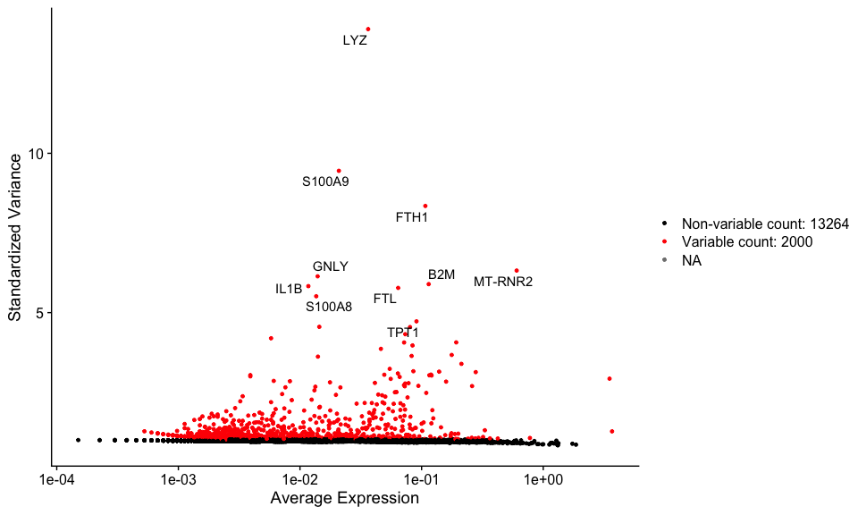

```r
# Find variable features, accepting default parameters to control the operation
# of the algorithm.
mrgobj <- FindVariableFeatures(mrgobj, nfeatures=2000, verbose=FALSE)
# VariableFeatures() is the default function the Seurat docs recommend for
# obtaining a list of the top 10 most variable features.  However, it sometimes
# returns a different list than the HVFInfo() function, which is what the
# VariableFeaturePlot() function uses internally for figuring out where to
# plot the points.  So we comment it out and use HVFInfo() instead in order
# to maintain consistency.
# top10 <- head(VariableFeatures(mrgobj), 10)
top10 <- HVFInfo(mrgobj, status=TRUE) %>%
         filter(variable==TRUE & rank<=10) %>%
         rownames()
pltfeatvar <- VariableFeaturePlot(mrgobj) %>%
              LabelPoints(points=top10, repel=TRUE, xnudge=0, ynudge=0)
print(pltfeatvar)
```

## Step 7: Dimensionality Reduction

Later in the analysis, we’d like to identify clusters of cells with similar feature values (i.e., similar transcript expression levels), however we have thousands of features to choose from, and that’s too many. To overcome this problem, we use Principal Components Analysis to identify linear combinations of features (a.k.a., the “principal components”) with the highest variance, ranking these in order of their variance, then we select a much smaller subset of the principal components to be treated as synthetic features which will be used as input for the clustering algorithm.

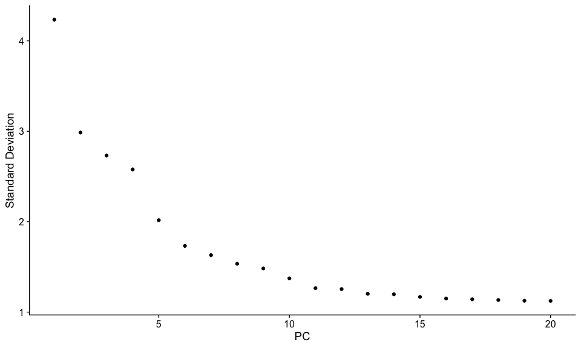

```r
# PCA works best with rescaled data
mrgobj <- ScaleData(mrgobj, features=rownames(mrgobj), verbose=FALSE)
# Here it's slightly unclear whether we should use the VariableFeatures()
# function, or the alternative technique with HVFInfo() that was previously
# illustrated above.
mrgobj <- RunPCA(mrgobj, features=VariableFeatures(object=mrgobj),
                 verbose=FALSE)
ElbowPlot(mrgobj)
```

## Step 8: Cluster the Cells

It’s presumed that cells with similar transcript expression profiles will usually correspond to the same tissue type, so that if a sample contains multiple types of cells, we can potentially identify each cell type by assigning each cell to a cluster ID, and identifying biomarkers in each cluster that are known to be associated with a specific tissue type.

In practice, we do this by finding the “nearest neighbors” of each barcoded cell as defined by of a reduced feature set consisting of the largest *n* PCA components. Groups of cells that are close together in PCA feature space are then assigned together to the same cluster ID.

Unfortunately, however, the *n* PCA components that are used to calculate nearest neighbor distances are still too high-dimensional to visualize, therefore we use another algorithm (e.g., UMAP, or tSNE) to project from *n* dimensions down into two dimensions. The results are then visualized using the `DimPlot()` function.

The `resolution` parameter controls the propensity to aggregate cells into more or fewer clusters; I was unsure of what value to choose, so I just fiddled with it manually until the resulting cluster divisions depicted in the UMAP and tSNE plots looked approximately like what I would be tempted to produce if I were drawing estimated cluster boundaries by hand.

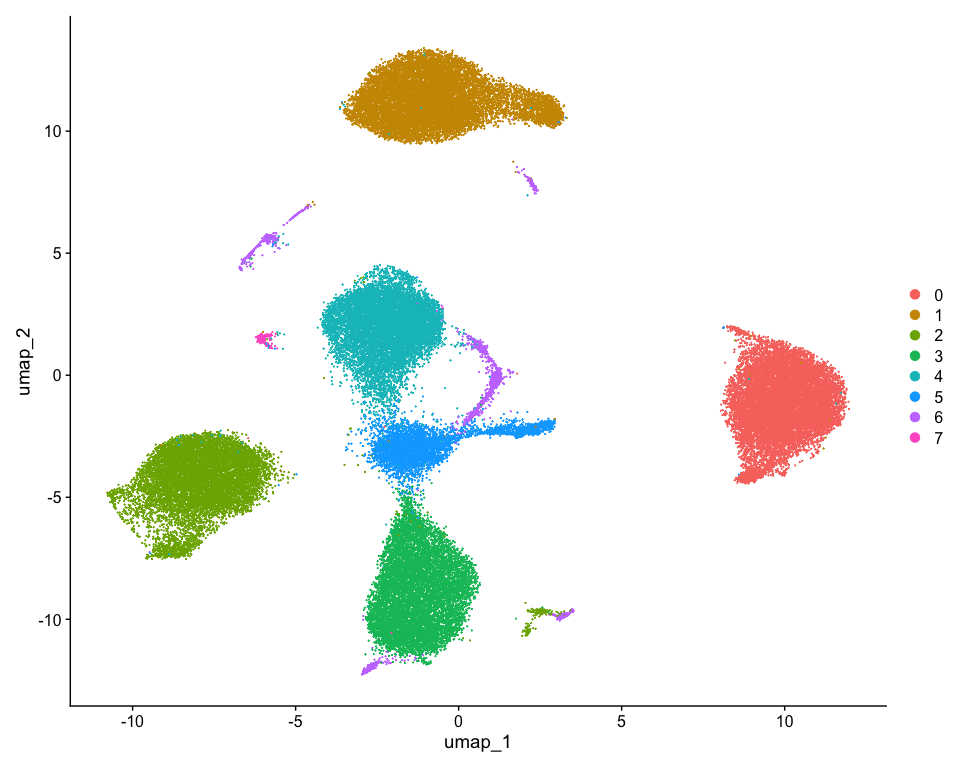

```r
# Find neighbors using first 10 PCA components, and identify clusters
mrgobj <- FindNeighbors(mrgobj, dims=1:10, verbose=FALSE) %>%
          FindClusters(resolution=0.1, verbose=FALSE)
# Run UMAP and TSNE, just to compare results
mrgobj <- RunUMAP(mrgobj, dims=1:10, verbose=FALSE) %>% suppressWarnings() %>%
          RunTSNE(dims=1:10, verbose=FALSE)
# Visualize output results
DimPlot(mrgobj, reduction="umap")
```

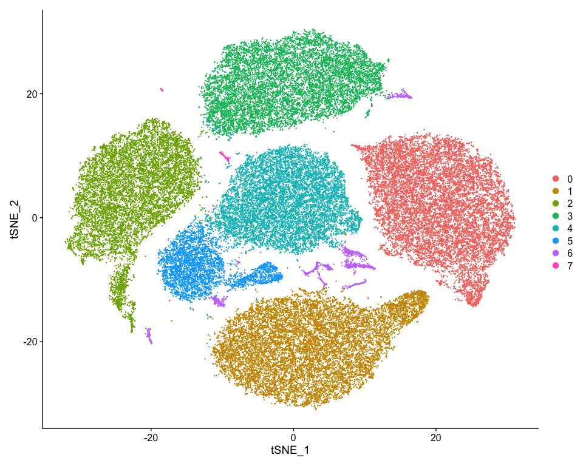

```r
DimPlot(mrgobj, reduction="tsne")
```

In many single cell RNA-seq analyses, it’s typically presumed that each cluster is associated with a specific cell type: i.e., one cluster represents epithelial cells, another cluster represents a specific type of immune cell, etc.

In this analysis, something unexpected seems to have happened. Each of the 6 panels below represents one of the six sample files. The 8 color-coded bars represent the 8 clusters identified previously above. The height of each bar represents the total number of cells in each sample that were assigned to each cluster. If the cluster IDs were representing different types of cells, then we’d expect that each sample would have some cells assigned to each cluster. However, that doesn’t seemed to have happened in this case; instead, each sample ID appears to map almost purely onto one cluster. Cluster 0 is essentially synonymous with sample ID `C3N-03184-02`, cluster 1 is essentially synonymous with sample ID `C3L-03405-01`, and so on. Evidently, the sample-to-sample variability in expression profiles is larger than the cell-type to cell-type variability in expression profile within each sample.

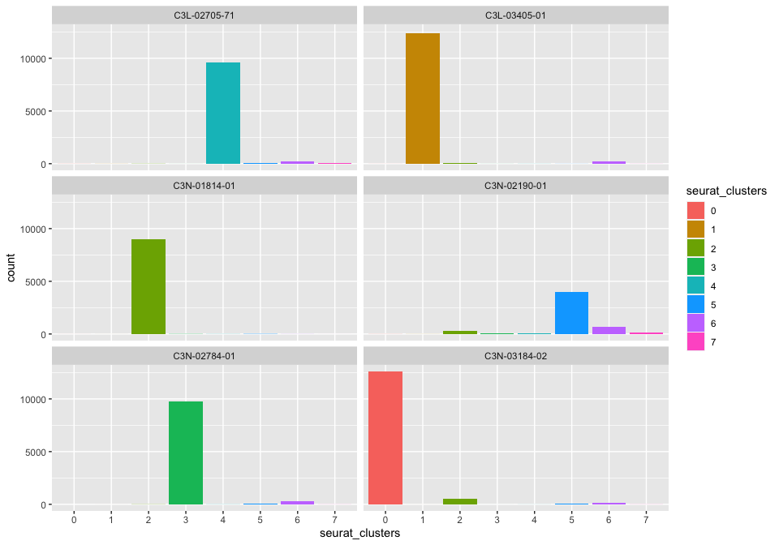

```r
# Grab metadata data frame again
df <- mrgobj@meta.data
plt_smpvscl <- ggplot(df) +
               geom_bar(aes(x=seurat_clusters, fill=seurat_clusters)) +
               facet_wrap(~Sample_ID, nrow=3)
print(plt_smpvscl)
```

## Step 9: Differential Expression

Many single cell RNA-seq analyses would use differential expression analysis at this point to try to generate an expression profile for each cluster, by assigning “biomarkers” (essentially, identifying a set of anomalously overexpressed transcripts) in each cluster. These biomarkers are then thought to be useful in identifying the type of cell represented by each cluster (e.g., red blood cells vs. neurons vs. immune cells, etc.)

In this case, given we’ve concluded above that each cluster identified in our clustering analysis just identifies a specific sample, we can’t do that. Instead, a differential expression analysis just gives the unique average expression signature associated with each tumor sample.

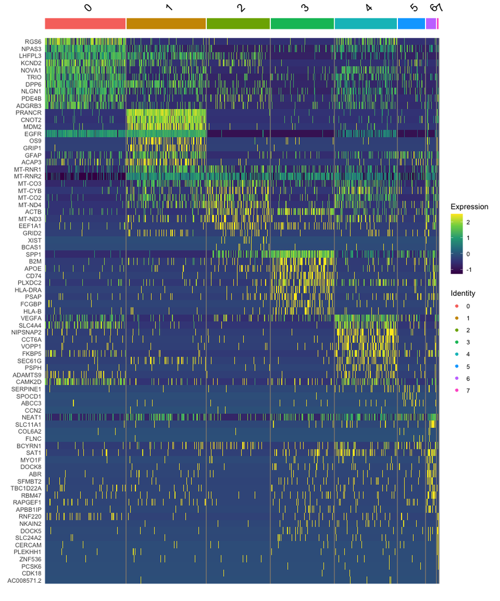

```r
# Required step in order to run FinaAllMarkers()
mrgobj <- JoinLayers(mrgobj)
# Find all positive biomarkers for each cluster
allmrk <- FindAllMarkers(mrgobj, only.pos=TRUE)
# The above list is typically prohibitively long to try to visualize, so
# cut it down to 10 biomarkers per cluster
top10 <- group_by(allmrk, cluster) %>%
         filter(avg_log2FC > 1) %>%
         slice_head(n=10) %>%
         ungroup()
# Make a heatmap that shows expression level vs. cell ID vs. biomarker vs.
# cluster ID
plt_diffexp <- DoHeatmap(mrgobj, features=top10$gene) +
               scale_fill_viridis_c()
print(plt_diffexp)
```